# index

Wei Duan

11/10/2019

## Summary Information

The dataset shooting contains information about mass shooting events from 2018 in United State of America. The original data source can be found [here](http://www.shootingtracker.com/). The dataset includes the date of incident, address, number of people killed, number of people injured, latitude, and longitude. In 2018, there were **340** occurred in the U.S. As a result, **373** lives were lost during these incidents. Statistically, the city of **Chicago** was most impacted by shootings - **135** were killed or injured in the shooting accidents. The measure of impacted is calculated by aggregating the number of people killed and injured based on the city category. Additionally, **California** has the highest number of people killed - **50** people were murdered in California. Also, Washington state has only 3 shooting incidents occurred back in 2018.

## Summary Table

Impact by Each State

| state | num_death | num_injury | total |
| --- | --- | --- | --- |
| California | 50 | 136 | 186 |
| Florida | 48 | 132 | 180 |
| Illinois | 21 | 150 | 171 |
| Pennsylvania | 35 | 63 | 98 |
| Texas | 29 | 62 | 91 |
| Tennessee | 19 | 68 | 87 |
| Alabama | 12 | 55 | 67 |
| Louisiana | 15 | 50 | 65 |
| Missouri | 12 | 52 | 64 |
| Ohio | 13 | 46 | 59 |
| New York | 5 | 53 | 58 |
| New Jersey | 4 | 54 | 58 |
| North Carolina | 14 | 37 | 51 |
| Maryland | 13 | 31 | 44 |
| Michigan | 10 | 28 | 38 |
| Indiana | 10 | 27 | 37 |
| Colorado | 9 | 27 | 36 |
| Georgia | 3 | 33 | 36 |
| Kentucky | 7 | 25 | 32 |
| District of Columbia | 2 | 23 | 25 |
| Arkansas | 7 | 17 | 24 |
| South Carolina | 5 | 19 | 24 |
| Oklahoma | 2 | 19 | 21 |
| Virginia | 2 | 17 | 19 |
| Nevada | 3 | 15 | 18 |
| Mississippi | 1 | 17 | 18 |
| Wisconsin | 1 | 16 | 17 |
| Nebraska | 1 | 16 | 17 |
| Minnesota | 1 | 14 | 15 |
| Washington | 4 | 9 | 13 |
| Kansas | 1 | 11 | 12 |
| New Mexico | 5 | 4 | 9 |
| Arizona | 4 | 5 | 9 |
| Connecticut | 0 | 8 | 8 |
| Delaware | 5 | 0 | 5 |
| Massachusetts | 0 | 4 | 4 |
| Utah | 0 | 4 | 4 |

The table above displays information about the aggregated number(sorted *by each state*) of people killed or injured during shooting incidents back in 2018. As we can see, state that had most people killed or injured during these incidents were **California, Florida, and Illinois**, respetcively. However, the mean value of impact is only **46.49**. Only 13 states had impact values greater than the mean, accounting only **a third of total states** where shootings occurred. Therefore, it is largely because of the top three extreme values. It is worthwhile for governments to investigate why California, Florida, and Illinois had such high impact values.

## Description of a Particular Incident

I decided to investigate the incident in which most people were killed. It turns out to be the incident happened at *5901 Pine Island Rd, Pompano Beach (Parkland), Florida on February 14, 2018.* In this tragedy, **17** people were murdered, and a total of **34** people were impacted(17 killed and 17 injured). The shooter was identifiled as Nikolas Cruz, who was 19-year-old expelled from the school. Further information and reportings can be found [here](https://www.nytimes.com/2018/02/14/us/parkland-school-shooting.html).

## An Interactive Map

[interactive chart not shown]

The interactive map shows the locations of shooting incidents, and the radius of the circle is postively correlated with the impact(number of people killed or injured) of the incident.

According to the map, first of all, we can find that **the eastern part of U.S. generally had more shooting incidents occurred.** This could be a indication that western and eastern sides had different levels of gun control.

Secondly, it is interesting to see that **coastal zones overall had greater impacts than inland areas did.** For example, Los Angelas, Santa Fe, Pompano Beach, and Trenton, which are all close to the coasts, had greater impacts than inland areas did.

## A Plot of My Choice

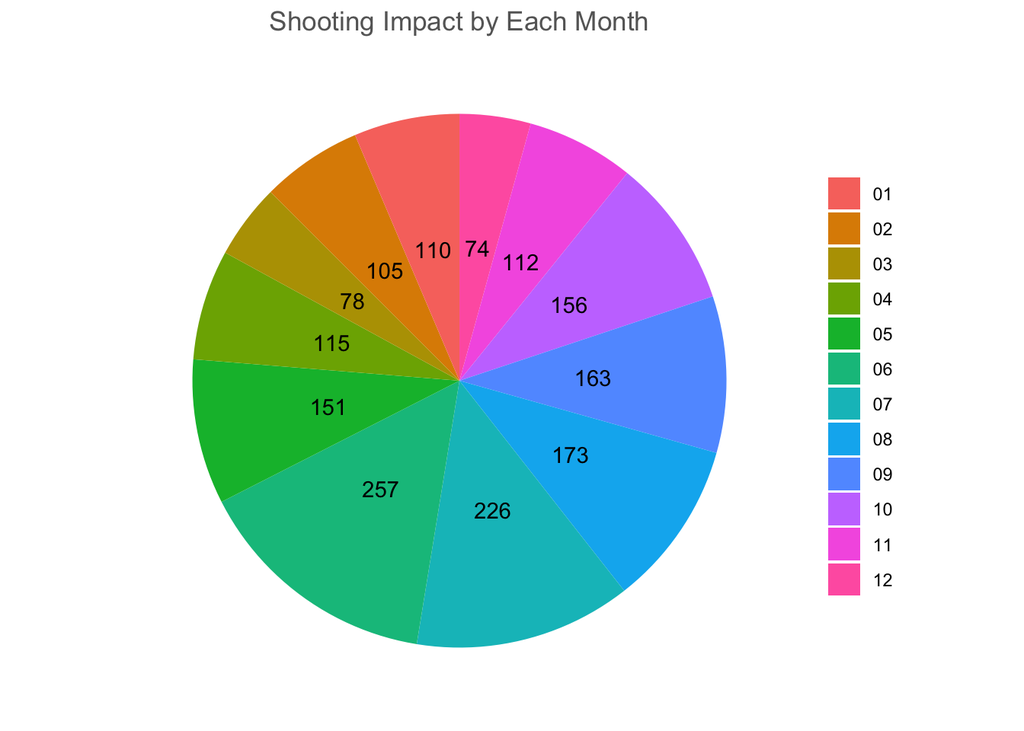

The plot above provides a straightfarword answer to the following question: **which months had the highest proportions of people killed or injured in the shooting events?** This plot is helpful because the plot distinguishes months by different color hues and it is obvious to readers that June and July had the most people impacted.

Firstly, we can easily recognize that many people were injured or murdered by shootings in the middle of 2018, whereas the beginning and end of 2018 had fewer people impacted than rest of the time.

## Critical Reflection

In the Chapter 5, Kathy talked about how predictive model, which were built with historical crime data, benefited the police department in preventing crimes from happening. Th predictive model could increase policemen’s efficiency, but in the meanwhile, some crimes that are not recordable in terms of data are ignored. Similarly, in the case of mass shooting data, my reporting, as well as other data can be used to analyze the causes, to predict future possible crimes, etc. However, if potential criminals see these published reportings, historical data, it is possible for them to commit crimes at those locations again. Mass shooting criminals usually want to make a negative impact on the society as a way to retaliate, if they see a past shooter made great impacts at a certain location, they may go to that location again, which is very harmful for the society.